# Analysing Cookie Cats

Eduard Corral, Marcel Feliu and Paula Ros.

2022-12-08

## 1. Getting to know the datasets

Before we start with the analysis, have a look at the structure of both datasets. First, upload the data sets in R. For a smoother correction on my side, please provide the data frames with the following names: • For dataset ’cookie_cats_ABtest.csv‘ use data frame variable named ’DS‘. • For dataset ’cookie_cats_purch.csv”, use data frame variable named ’PR‘. For each dataset, show and describe the information that they contain: rows and columns of the dataset, and types of variables.

```r
  DS <- read.csv("cookie_cats_ABtest.csv", sep = ",")
  PR <- read.csv("cookie_cats_purch.csv", sep = ",")

  str(DS)
```

```
## 'data.frame':    90189 obs. of  5 variables:
##  $ userid        : int  116 337 377 483 488 540 1066 1444 1574 1587 ...
##  $ version       : chr  "gate_30" "gate_30" "gate_40" "gate_40" ...
##  $ sum_gamerounds: int  3 38 165 1 179 187 0 2 108 153 ...
##  $ retention_1   : chr  "FALSE" "TRUE" "TRUE" "FALSE" ...
##  $ retention_7   : logi  FALSE FALSE FALSE FALSE TRUE TRUE ...
```

```r
  str(PR)
```

```
## 'data.frame':    4563 obs. of  2 variables:
##  $ id   : int  5696479 6682624 1698475 4520146 5081239 1177780 4334785 331668 45698 6170568 ...
##  $ purch: chr  "10.99EUR" "2.29EUR" "2.29EUR" "10.99EUR" ...
```

## 2. Preprocessing

Before we start with the analysis, revise the structure and contents of the data sets to look for inconsistencies, missing values, or errors, and if necessary, perform the necessary transformations. You should also check that all IDs of the second data set (cookie_cats_purch) are valid IDs (i.e., existing IDs in cookie_cats_ABtest). If you apply any transformation, you should include a proper explanation in your report.

### 2.1. Preprocessing dataset “Cookie Cats AB Testing”

First of all, we used the function is.na() to locate the rows that had NA and then, we deleted them.

```r
  naUserid <- which(is.na(DS$userid)) ; naUserid
```

```
## [1]  300  783 9878
```

```r
  DS <- DS[-naUserid, ]
```

After that, we used the function table() to look at the different variables to discover any more inconsistencies. We discovered that the variable called “retention_1” had two versions of TRUE and two versions of FALSE, ones with lowercase letters and spaces and the others correct, with capital letters. The following code shows the process on preprocessing the content of this variable.

```r
  table(DS$retention_1)
```

```
##
##   true    FALSE  false     TRUE
##       7   50022      13   40144
```

```r
  DS$retention_1[DS$retention_1 == "false "] = FALSE
  DS$retention_1[DS$retention_1 == "  true "] = TRUE
  table(DS$retention_1)
```

```
##
## FALSE  TRUE
## 50035 40151
```

Finally, we deleted one value from the sum_gamerounds that was too big and had no consistence compared to the rest of the values.

```r
  DS <- DS[-which.max(DS$sum_gamerounds), ]
```

### 2.2. Preprocessing dataset “Cookie Cats Purchases”

For the “Cookie Cats Purchases” dataset we discovered that the NA from the previous dataset were included too in this one. We obtained the positions of this variables and deleted their rows.

```r
  inexistentValues <- which((PR$id %in% DS$userid) == FALSE) ; inexistentValues
```

```
## [1] 310 595 926
```

```r
  PR <- PR[-inexistentValues, ]
  which((PR$id %in% DS$userid) == FALSE)
```

```
## integer(0)
```

In addition, we deleted the NAs that were in the column purch.

```r
  naPurch <- which(is.na(PR$purch)) ; naPurch
```

```
## [1]  20  39 163 421 460
```

```r
  PR <- PR[-naPurch, ]
```

Moreover, we changed the column purch that was formed by characters to a numerical one, deleting the EUR.

```r
  PR['purch'] <-  as.numeric(gsub("[a-zA-Z]","", PR$purch))
```

We changed the negative values into positive because it didn’t make sense to buy in negative.

```r
  PR$purch[PR$purch < 0] <- -(PR$purch[PR$purch < 0])
  unique(PR$purch)
```

```
## [1]  10.99   2.29  54.99  21.99 109.99
```

Finally, we detected that there were some ids that were repeated. We have interpreted that those users did more than one purch. We decided to sum both purch values and merge them in one row.

We duplicated the dataset in order to have the original without the merge for the descriptive analytics.

```r
  library(dplyr)
  PR.different.purch <- PR
  PR <- PR %>% group_by(id) %>%
  summarise(purch=sum(purch)) %>%
  as.data.frame()
```

### 2.3 Merge the datasets

First of all, we used the library dplyr in order to merge the two datasets. We decided to create two new datasets, one with all the population (merge.all) and another with just the users that did a purchase in the game (merge.purch), with the two datasets we will compare both models to know which has the best linear model. In the dataset with all the population we changed the NAs values from purch to 0 EUR.

```r
  library(dplyr)
  merge.all <-merge(DS,PR,by.x="userid",by.y="id", all = TRUE)
  merge.all$purch[is.na(merge.all$purch)] <- 0

  merge.purch = merge(DS,PR,by.x="userid",by.y="id")

  #write.csv(merge.all,"D:/uni/QUART/merged_dataset.csv", row.names = FALSE)
  #write.csv(merge.purch,"D:/uni/QUART/merged_justpurch_dataset.csv", row.names = FALSE)
```

## 3. Descriptive Analytics

Perform descriptive analytics of the datasets visually and numerically. To make this task simpler, we’ll do the analysis for each data set separately.

### 3.1. Dataset “Cookie Cats AB Testing”

#### 3.1.1 Users that downloaded the game

There are 90.185 users that downloaded the Cookie Cats game.

```r
  nrow(DS)
```

```
## [1] 90185
```

#### 3.1.2 Distribution of users in groups

From the 90.185 users, 44698 played the gate number 30 and 45.487 played the gate number 40.

```r
  table(DS$version)
```

```
##
## gate_30 gate_40
##   44698   45487
```

#### 3.1.3 Game rounds

The next step was calculating the distribution of game rounds in the players’ population in a boxplot to show it in a visual way. We also calculated the distribution of game rounds among the users of version A (gate_30) and version B (gate_40) of the game separately and compared them.

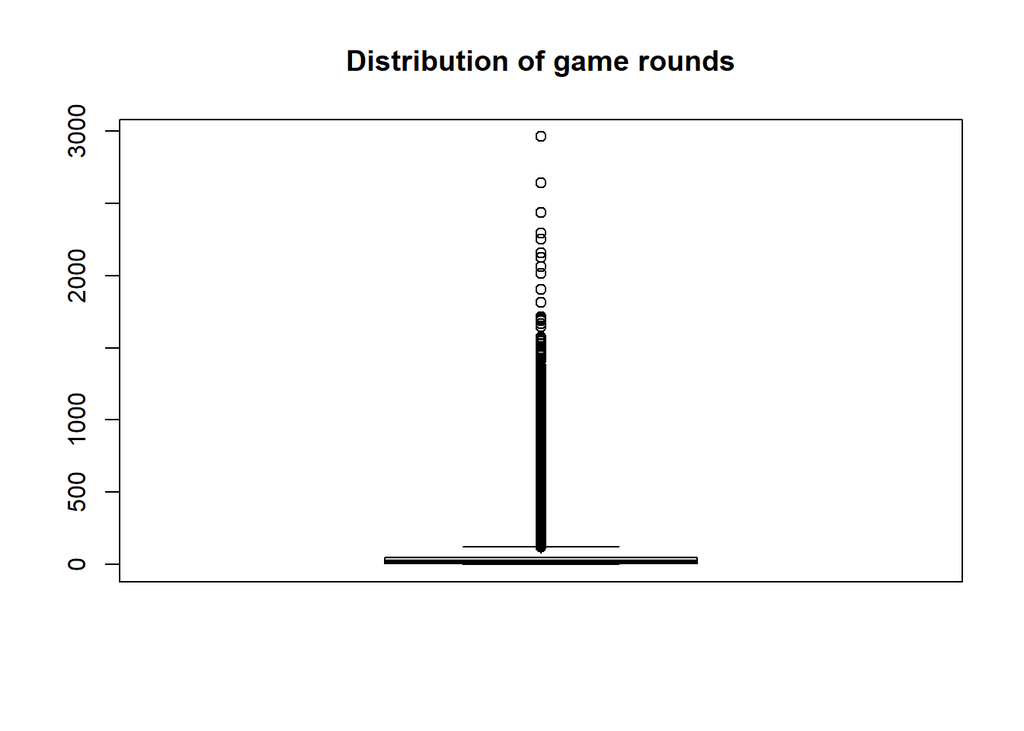

```r
  boxplot(DS$sum_gamerounds, main = "Distribution of game rounds")
```

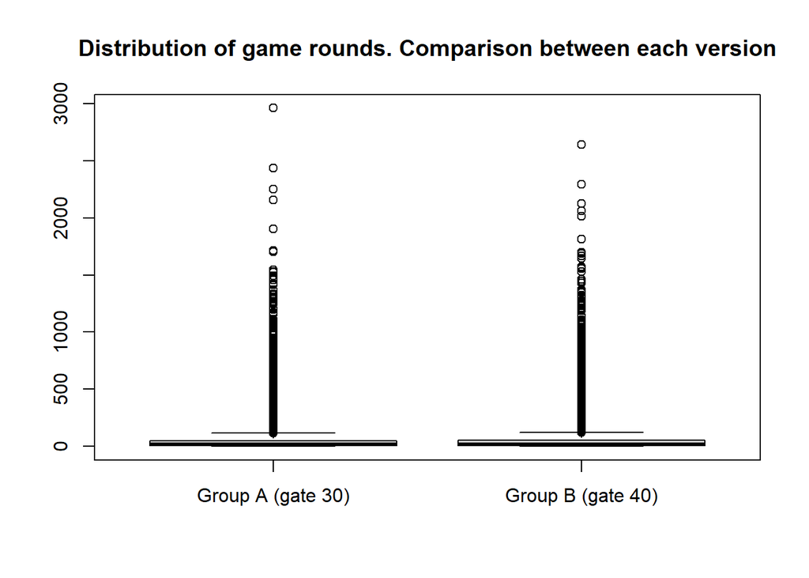

```r
  groupA <- DS$sum_gamerounds[DS$version == "gate_30"]
  groupB <- DS$sum_gamerounds[DS$version == "gate_40"]
  boxplot(groupA, groupB, names = c("Group A (gate 30)", "Group B (gate 40)"), main = "Distribution of game rounds. Comparison between each version")
```

#### 3.1.4 Retention (day 1 and day 7)

What is the value of retention at day 1? (percentage of users that are still active the day after installation).

```r
  activeUsersDay1 <- sum(DS$retention_1 == TRUE)
  totalUsers <- nrow(DS)
  percentageRetentionDay1 <- activeUsersDay1 * 100 / totalUsers
  paste(as.character(round(percentageRetentionDay1, 3)),"%")
```

```
## [1] "44.521 %"
```

What is the value of retention at day 7? (percentage of users that are still active after one week of installation).

```r
  activeUsersDay7 <- sum(DS$retention_1 == TRUE & DS$retention_7 == TRUE)
  percentageRetentionDay7 <- activeUsersDay7 * 100 / totalUsers
  paste(as.character(round(percentageRetentionDay7, 3)),"%")
```

```
## [1] "14.617 %"
```

#### 3.1.5 Are there non-playing users?

To see if there are non-playing users, we look for those who had both retention at day 1 and at day 7 as FALSE.

```r
  non.playing.users <- sum(DS$retention_1 == FALSE & DS$retention_7 == FALSE) ; non.playing.users
```

```
## [1] 46436
```

Finally, to compute the percentage, we just have to multiply the non-playing users for 100 and then divide it for the total users.

```r
  percentageNonPlayingUsers <- non.playing.users * 100 / totalUsers
  paste(as.character(round(percentageNonPlayingUsers, 2)),"%")
```

```
## [1] "51.49 %"
```

### 3.2 Dataset “Cookie Cats Purchases”

#### 3.2.1 Percentage purchase quantities

To do the descriptive analysis we start by computing how many and the percentage of each purchase quantity. To do so, we get how many purchases of the same amount are made. After that, we can easily compute the percentage of each purchase amount. Once we finished we used a barplot to show the data.

```r
  num.users.DS <- nrow(DS)
  num.users.PR <- nrow(PR)
  c(num.users.DS, num.users.PR)
```

```
## [1] 90185   991
```

```r
  purch.2.29 <- sum(length(PR.different.purch$purch[PR.different.purch$purch == "2.29"])) * 100 / nrow(PR.different.purch)
  purch.10.99 <- sum(length(PR.different.purch$purch[PR.different.purch$purch == "10.99"])) * 100 / nrow(PR.different.purch)
  purch.21.99 <- sum(length(PR.different.purch$purch[PR.different.purch$purch == "21.99"])) * 100 / nrow(PR.different.purch)
  purch.54.99 <- sum(length(PR.different.purch$purch[PR.different.purch$purch == "54.99"])) * 100 / nrow(PR.different.purch)
  purch.109.99 <- sum(length(PR.different.purch$purch[PR.different.purch$purch == "109.99"])) * 100 / nrow(PR.different.purch)

  purch.quantities <- c(purch.2.29, purch.10.99, purch.21.99, purch.54.99, purch.109.99)

  myLables <- c("2,29$ ", "10,99$ ", "21,99$ ", "54,99$ ", "109,99$ ")
  myLables2 <- paste(round(purch.quantities),"%", sep = "")
  myLables2
```

```
## [1] "46%" "28%" "18%" "5%"  "3%"
```

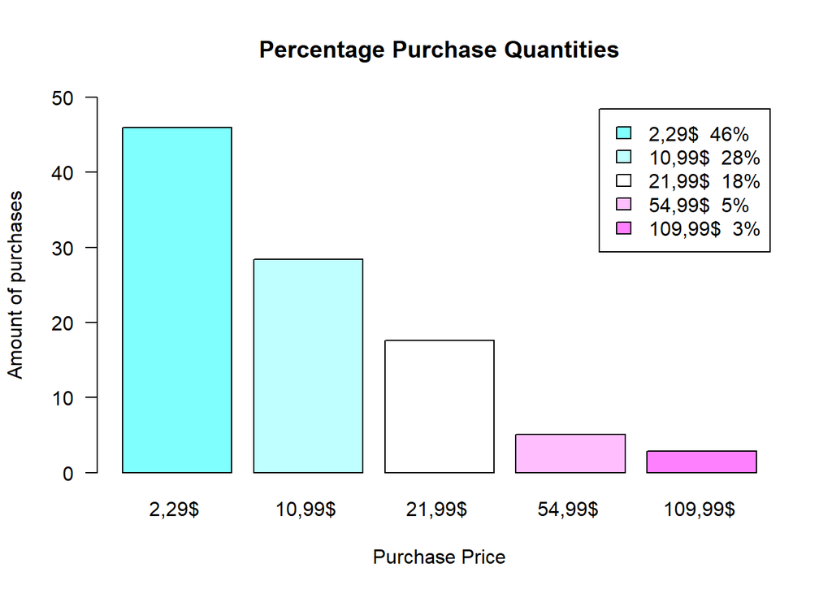

```r
  myLables3 <- paste(myLables, myLables2)

  barplot(purch.quantities, names = myLables, col = cm.colors(length(purch.quantities)), legend.text = myLables3, ylim = c(0, 50), main = "Percentage Purchase Quantities", ylab = "Amount of purchases", xlab = "Purchase Price", las = 1)
```

#### 3.2.2 Multiple purchases percentage

```r
  repeated <- length(table(PR.different.purch$id))
  single <- nrow(PR.different.purch) - repeated
  c(repeated, single)
```

```
## [1]  991 3564
```

```r
  percentage.multiple.purchases <- repeated * 100 / nrow(PR.different.purch)
  pct.paying.users <- (nrow(PR.different.purch)-repeated) * 100 / nrow(PR.different.purch)

  total.pct <- round(c(pct.paying.users, percentage.multiple.purchases),)

  lable1 <- c("Unique purchase", "Multiple Purchase")
  lable2 <- paste(total.pct, "%", sep = "") ; lable2
```

```
## [1] "78%" "22%"
```

```r
  lable3 <- paste(lable1, lable2) ; lable3
```

```
## [1] "Unique purchase 78%"   "Multiple Purchase 22%"
```

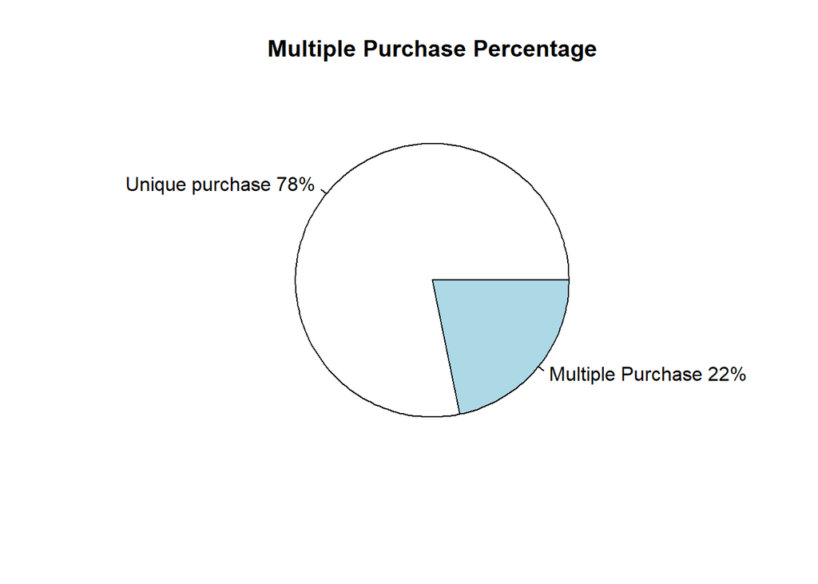

```r
  pie(c(pct.paying.users, percentage.multiple.purchases), lable3, main = "Multiple Purchase Percentage")
```

#### 3.2.3 Quantity of money spent

Then we decided to show the mean, max and min of the money spent. After computing all the numbers we put it in a table we created with the kable function.

```r
  mean <- round(mean(PR$purch),1)
  max <- round(max(PR$purch),1)
  min <- round(min(PR$purch),1)

  money.data <- data.frame(mean, max, min)
  knitr::kable(money.data, format = "pipe", col.names = c("Mean", "Max", "Min"), align = c("l", "c", "c"))
```

| Mean | Max | Min |
| --- | --- | --- |
| 64.5 | 933.9 | 2.3 |

Finally, we made a list with the top 3 of the three most expensive purchases. We used a boxplot to compare the purchases between the two versions of the game.

```r
  top3.max.purchase <- round(sort(PR$purch, decreasing = TRUE),)[1:3] ; top3.max.purchase
```

```
## [1] 934 628 623
```

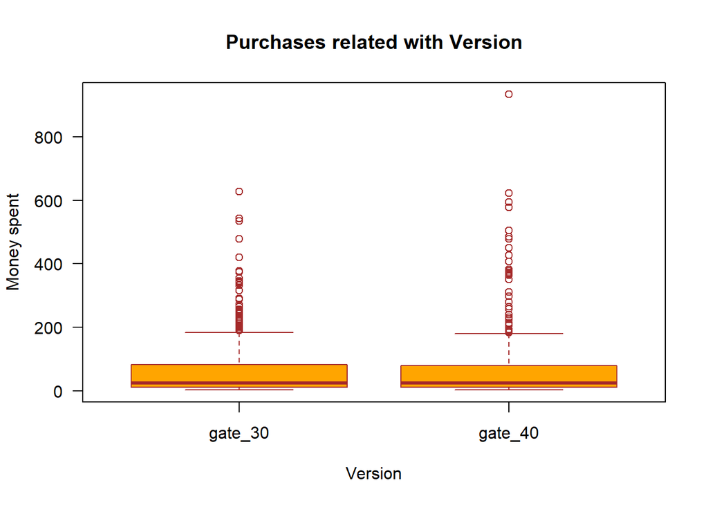

```r
  boxplot(merge.purch$purch ~ merge.purch$version, main = "Purchases related with Version", xlab="Version", ylab="Money spent", col="orange", border="brown", las = 1)
```

## 4. Monetization metrics

#### 4.1 Conversion Rate

In order to compute the conversion rate, we need to compare the paying users with the total population of the game. We do it by dividing the length of PR table with the sum of the sum of both tables; PR and DS.

```r
  num.users.DS <- nrow(DS)
  num.users.PR <- nrow(PR)

  PR.AND.DS.USERS <- sum(num.users.DS, num.users.PR)

  conversion.rate <- (num.users.PR / PR.AND.DS.USERS) * 100
  conversion.rate <- paste(as.character(round(conversion.rate, 2)), "%") ; conversion.rate
```

```
## [1] "1.09 %"
```

#### 4.2 ARPU

By dividing the total revenue by the total population of the game, we can see the amount of money spent by user.

```r
  total.revenue <- sum(PR$purch)
  ARPU <- total.revenue / PR.AND.DS.USERS
  ARPU <- round(ARPU, digit = 2) ; ARPU
```

```
## [1] 0.7
```

#### 4.3 ARPPU

To see the amount of money spent by paying user, we just have to divide the total revenue, like before, but by the amount of paying users.

```r
  ARPPU <- total.revenue / num.users.PR
  ARPPU <- round(ARPPU, digit = 2) ; ARPPU
```

```
## [1] 64.46
```

We did a simple table with the Kable function to show the data.

```r
  MM <- data.frame(conversion.rate, ARPU, ARPPU)
  knitr::kable(MM, format = "pipe", col.names = c("Conversion Rate", "ARPU", "ARPPU"), align = c("l", "c", "c"))
```

| Conversion Rate | ARPU | ARPPU |
| --- | --- | --- |
| 1.09 % | 0.7 | 64.46 |

## 5. A/B testing

In this section, we aim at answering Researh Question 8: “Does moving gate to level 40 improve engagement of the users significantly?

The designers of the game are interested in knowing whether moving the gate to level 40 has improved the engagement of the users. Thus, we will perform an A/B test to answer the research question, considering engagement as the number of round games of every user. Thus, we would like to know whether moving the gate to level 40 increases engagement with 95% confidence level.

### 5.1 Hypotheses

In order to realize the A/B testing, it is necessary to propose an alternative and null hypothesis.

Null hypothesis:

- Gate 40 doesn’t improve the engagement of the users.
- H₀: engagement (number of game rounds) gate 40 <= engagement (number of game rounds) gate 30

Alternative hypothesis:

- Gate 40 improves the engagement of the users.
- H₁: engagement (number of game rounds) gate 40 > engagement (number of game rounds) gate 30

Other aspects to be taken in account:

- Testing of two samples (because there is gate 40 and gate 30)
- One tail.

### 5.2 Visualisation

Before realizing any computation, first of all, we will create different graphics in order to have a clear visualisation of the variables and investigate whether there seem to be differences on game rounds between the different groups.

In the following boxplot, we can see the different distribution between Group A (gate_30) and Group B (gate_40):

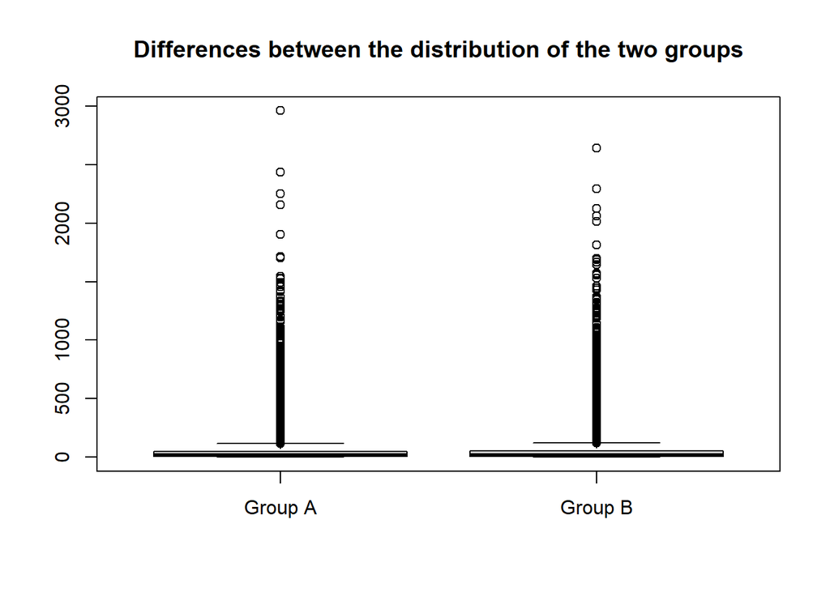

```r
 boxplot(groupA, groupB, names = c("Group A", "Group B"), main = "Differences between the distribution of the two groups")
```

In the following pie chart, we can observe the different percentages of maximum retention between each group. For us, the maximum retention is when the retention of the day one and seven are true, which means that the user has been active the maximum of days possible.

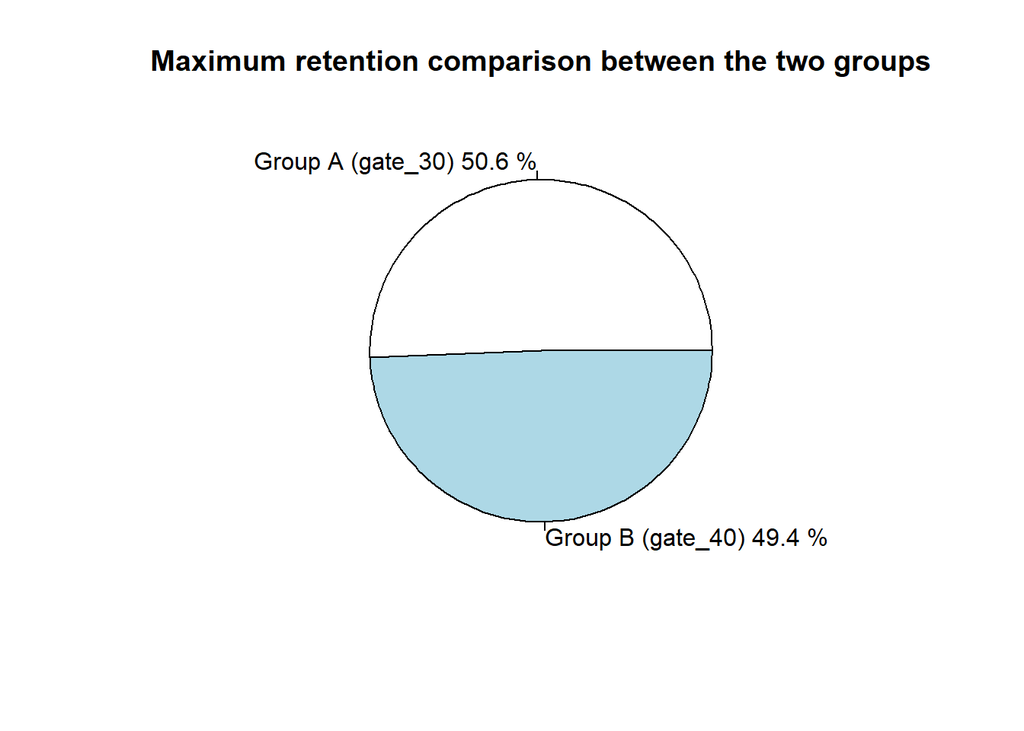

```r
 GroupAtotalUsersRetention<-length(DS$userid[DS$retention_1=="TRUE" & DS$retention_7 =="TRUE" & DS$version == "gate_30"])
 GroupBtotalUsersRetention<-length(DS$userid[DS$retention_1=="TRUE" & DS$retention_7 =="TRUE" & DS$version == "gate_40"])
 totalUsersWithMaxRetention<- c(GroupAtotalUsersRetention,GroupBtotalUsersRetention)
 pie(totalUsersWithMaxRetention,labels=c(paste(
   "Group A (gate_30)",round(GroupAtotalUsersRetention/(GroupAtotalUsersRetention+GroupBtotalUsersRetention),digits = 3)*100,"%"),
                     paste( "Group B (gate_40)",round(GroupBtotalUsersRetention/(GroupAtotalUsersRetention+GroupBtotalUsersRetention),digits = 3)*100,"%")),
     main = "Maximum retention comparison between the two groups")
```

In the following pie chart, we show is what is the percentage of the total of game rounds played by each group:

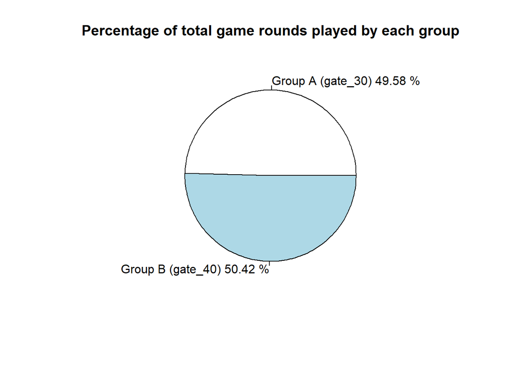

```r
 GroupASumGameRounds<-sum(DS$sum_gamerounds[ DS$version == "gate_30"])
 GroupBSumGameRounds<-sum(DS$sum_gamerounds[ DS$version == "gate_40"])
totalGameRounds <- GroupASumGameRounds+GroupBSumGameRounds
 gameRoundsVector<- c(GroupASumGameRounds,GroupBSumGameRounds)
 aTmp<-paste("Group A (gate_30)",round(GroupASumGameRounds/totalGameRounds,digits = 4)*100,"%")
 bTmp<-paste("Group B (gate_40)",round(GroupBSumGameRounds/totalGameRounds,digits = 4)*100,"%")
 pie(gameRoundsVector,labels=c( aTmp, bTmp), main = "Percentage of total game rounds played by each group")
```

### 5.3 Computation

In order to realize the computation, we will apply the A/B testing hypothesis method, computing and showing all the necessary values: the observed statistic, the p value, etc.

First of all, we will compare both groups to decide if we need to use an unequal variance or an equal variance:

```r
length(DS$userid[DS$version=="gate_30"])
```

```
## [1] 44698
```

```r
length(DS$userid[DS$version=="gate_40"])
```

```
## [1] 45487
```

Finally, we decide to use the unequal variance, because the different groups don’t have the same amount of users. In the following code, we calculate the mean and the standard deviation for both groups and also the observed value (Tobs) and finally, the degrees of freedom.

```r
meanGroupA<- mean(DS$sum_gamerounds[DS$version=="gate_30"] )
meanGroupA
```

```
## [1] 51.34131
```

```r
meanGroupB<- mean(DS$sum_gamerounds[DS$version=="gate_40"] )
meanGroupB
```

```
## [1] 51.29949
```

```r
s1<-sd(DS$sum_gamerounds[DS$version=="gate_30"])
s2<-sd(DS$sum_gamerounds[DS$version=="gate_40"])

Tobs<-(meanGroupA-meanGroupB)/sqrt(s1^2/meanGroupA + s2^2/meanGroupB)
Tobs
```

```
## [1] 0.002063177
```

```r
degreesOfFredom<-(s1^2/meanGroupA + s2^2/meanGroupB)^2 /
  ( ((s1^2/meanGroupA)^2/meanGroupA-1) + ((s2^2/meanGroupB)^2/(meanGroupB-1) ))
degreesOfFredom
```

```
## [1] 101.6496
```

After calculating the previous values, we realize a comparasion between the observed value and the normal distribution, using the upper tail.

```r
Talpha = qt ( 0.05, df=degreesOfFredom,lower.tail=FALSE )
Talpha
```

```
## [1] 1.659982
```

The necessary condition to reject H0 is sumGameRounds gate 40 > sumGameRounds gate 30

```r
h0CanBeRejected<-Tobs>Talpha
h0CanBeRejected
```

```
## [1] FALSE
```

For verification of the analysis we do a double check, now using the pvalue and alpha to see if the results are the same

```r
p<-pt(Tobs,df=degreesOfFredom,lower.tail=FALSE)
p
```

```
## [1] 0.4991789
```

```r
alpha <- 0.005
canRejectH0WithPvalue <- p<alpha
canRejectH0WithPvalue
```

```
## [1] FALSE
```

To reject H0 p needs to be lower than alpha, in this case H0 can’t be rejected

## 6. Regression analysis

In this section, we aim at answering Research Question 9: “Can the amount of in-app purchases be related to the number of game rounds of the players?” Thus, we would like to investigate whether the amount of in-app purchases depends somehow on the number of game rounds. In order to answer this question, we will use the regression analysis.

In this analysis we will use the merged datasets called merge.all and merge.purch, created in the 2.3 section.

### 6.1 Visual representation

Before building the model, we have represented visually the potential relationship between the total amount spent by the user and the number of game rounds using a plot.

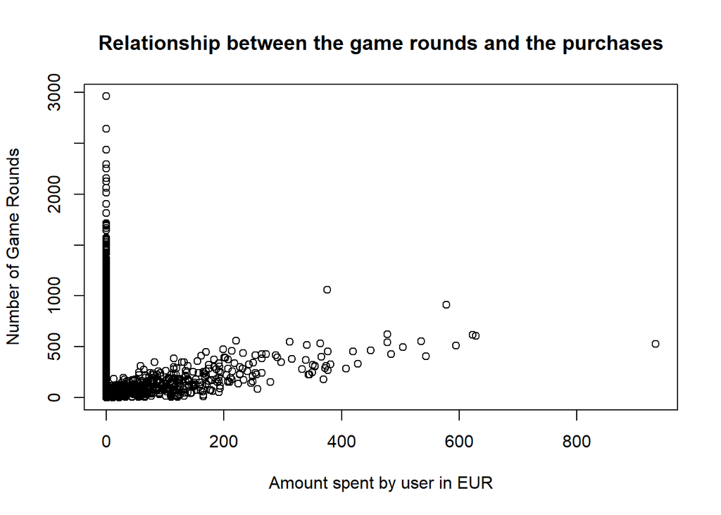

```r
  plot(merge.all$purch, merge.all$sum_gamerounds, ylab = "Number of Game Rounds", xlab = "Amount spent by user in EUR", main = "Relationship between the game rounds and the purchases")
```

After looking at the results of the graph, we can observe that most of the users spend 0 EUR and play from 0 to 3000 game rounds. In the other side, the rest of the users play less than 250 game rounds and spend approximately between 0 and 200 EUR. The users that spend the most are not in the majority group, as the graph shows, their values are spread over the plot, disregarding some exceptions, these users play around 250 and 600 game rounds, and spend between 200 and 620 EUR. We can intuit that there is no a direct relationship between playing more game rounds and spending more money, because the users who play more rounds do not even spend 1 EUR.

### 6.2 Building the model

We have developed two models with linear regression analysis. One taking into account all users (lm.all) and the other taking into account only those who have made in-game purchases(lm.just.purch).

```r
  lm.all <- lm(purch ~ sum_gamerounds, merge.all)
  lm.all
```

```
##
## Call:
## lm(formula = purch ~ sum_gamerounds, data = merge.all)
##
## Coefficients:
##    (Intercept)  sum_gamerounds
##        0.11536         0.01155
```

```r
  lm.just.purch <- lm(purch ~ sum_gamerounds, merge.purch)
  lm.just.purch
```

```
##
## Call:
## lm(formula = purch ~ sum_gamerounds, data = merge.purch)
##
## Coefficients:
##    (Intercept)  sum_gamerounds
##         3.6990          0.6983
```

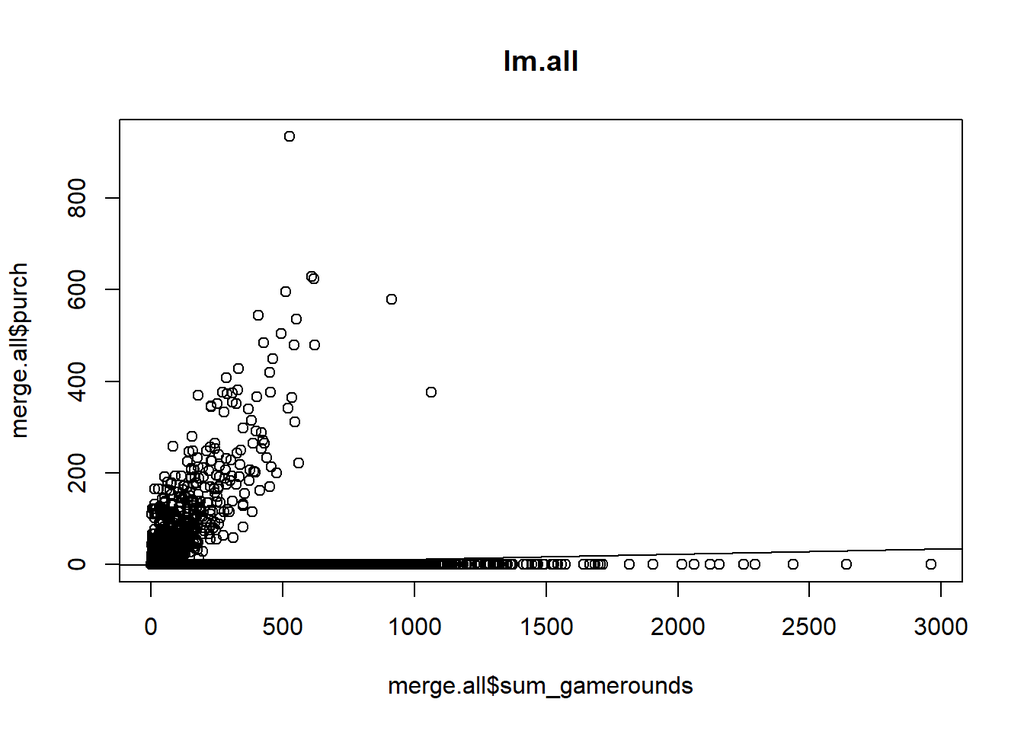

```r
  plot(merge.all$sum_gamerounds, merge.all$purch, main = "lm.all")
  abline(lm.all)
```

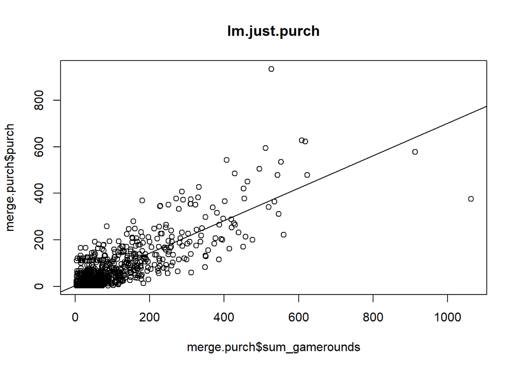

```r
  plot(merge.purch$sum_gamerounds, merge.purch$purch, main = "lm.just.purch")
  abline(lm.just.purch)
```

### 6.3 Model fit

In order to evaluate the quality of the models, we used the function summary():

```r
  summary(lm.all)
```

```
##
## Call:
## lm(formula = purch ~ sum_gamerounds, data = merge.all)
##
## Residuals:
##    Min     1Q Median     3Q    Max
## -34.32  -0.69  -0.30  -0.16 927.65
##
## Coefficients:
##                 Estimate Std. Error t value Pr(>|t|)
## (Intercept)    0.1153631  0.0446638   2.583   0.0098 **
## sum_gamerounds 0.0115532  0.0003891  29.694   <2e-16 ***
## ---
## Signif. codes:  0 '***' 0.001 '**' 0.01 '*' 0.05 '.' 0.1 ' ' 1
##
## Residual standard error: 12 on 90183 degrees of freedom
## Multiple R-squared:  0.009682,   Adjusted R-squared:  0.009671
## F-statistic: 881.7 on 1 and 90183 DF,  p-value: < 2.2e-16
```

```r
  summary(lm.just.purch)
```

```
##
## Call:
## lm(formula = purch ~ sum_gamerounds, data = merge.purch)
##
## Residuals:
##     Min      1Q  Median      3Q     Max
## -370.37  -22.02   -7.38    9.67  562.16
##
## Coefficients:
##                Estimate Std. Error t value Pr(>|t|)
## (Intercept)     3.69905    2.19843   1.683   0.0928 .
## sum_gamerounds  0.69828    0.01549  45.090   <2e-16 ***
## ---
## Signif. codes:  0 '***' 0.001 '**' 0.01 '*' 0.05 '.' 0.1 ' ' 1
##
## Residual standard error: 54.68 on 989 degrees of freedom
## Multiple R-squared:  0.6727, Adjusted R-squared:  0.6724
## F-statistic:  2033 on 1 and 989 DF,  p-value: < 2.2e-16
```

After looking at the results of the function summary(), the goodness of fit is given by the value of the R-squared, that is a measure of how close the data is to the fitted regression line.

We can observe that the linear model formed by all the users (lm.all) has a R-squared of 0.009682 and the second linear model only formed by the users that realized purchases in the game (lm.just.purch) has a R-squared of 0.6727. The best R-square value is the second one, because it is the one nearest to 1, the maximum R-squared value.

Finally, we can conclude that the best linear model is the one called lm.just.purch, only formed by the users that realized purchases in the game.

### 6.4 Predict a case

We have predicted a case of how much a user would spend if he or she had been playing 50 game rounds. In the following code we realized the prediction, obtaining the result that the user would spend 38.61 EUR, based on the linear model made of the users that realized any purchase (lm.just.purch).

```r
  invest <- 50
  new.ds <- data.frame(sum_gamerounds=invest)
  prediction = predict(lm.just.purch, new.ds)
  prediction <- round(prediction, digits = 2)
  prediction
```

```
##     1
## 38.61
```

### 6.5 Simulation

We have realized a simulation of how much a player would spend for different game rounds, ranging from 0 until 1000, every 50 rounds. To observe the results, we have created a table of the amount of game rounds and the total amount of money that the user would spend.

```r
  simulation.gamerounds <- seq(from = 0, to = 1000, by = 50)
  new.ds <- data.frame(sum_gamerounds=simulation.gamerounds)
  simulation.purch <- predict(lm.just.purch, new.ds)
  simulation.purch <- round(simulation.purch, digits = 2)

  ds.simulation <- data.frame(simulation.gamerounds, simulation.purch)
  names(ds.simulation)[1] <- "Game Rounds"
  names(ds.simulation)[2] <- "Purch"

  knitr::kable(ds.simulation, "simple", align = "lccrr", caption = "Purch simulation from 0 until 1000 game rounds")
```

Purch simulation from 0 until 1000 game rounds

| Game Rounds | Purch |
| --- | --- |
| 0 | 3.70 |
| 50 | 38.61 |
| 100 | 73.53 |
| 150 | 108.44 |
| 200 | 143.35 |
| 250 | 178.27 |
| 300 | 213.18 |
| 350 | 248.10 |
| 400 | 283.01 |
| 450 | 317.92 |
| 500 | 352.84 |
| 550 | 387.75 |
| 600 | 422.66 |
| 650 | 457.58 |
| 700 | 492.49 |
| 750 | 527.41 |
| 800 | 562.32 |
| 850 | 597.23 |
| 900 | 632.15 |
| 950 | 667.06 |
| 1000 | 701.97 |

We also created a plot to have a visual representation of the evolution of the amount of purchases that the user does in relation to the number of game rounds that plays. We can observe that there is a clear relationship between the two variables, where the values increase in a linear way.

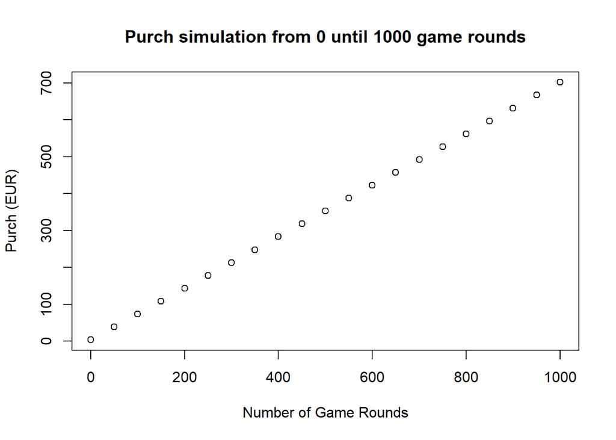

```r
  plot(ds.simulation, ylab = "Purch (EUR)", xlab = "Number of Game Rounds", main = "Purch simulation from 0 until 1000 game rounds")
```

## 9. Team contribution

In order to realize this final project, first of all, one member of the group created the Rmd file, created the structure of the project and realized the first section called “1. Getting to know the datasets”.

Then, in class, we decided to realize the second section of the project, the preprocessing, collectively, in order to take advantage of the free time of the data analysis class.

After finishing this part, we divided the following four sections (descriptive analytics, monetization metrics, A/B testing and regression analysis) among the three members of the team, in order to make the best use of our time and, at the same time, helping each other with any problem or doubt.

After developing those sections, we realized the dashboard and conclusion jointly too again, in order to end the project together and understand every part of the work by sharing the different results.

In summary, the different parts that realized each member are the following ones:

Marcel Feliu Saperas:

- Preprocessing.
- Descriptive Analytics (part 3.1 and 3.2)
- Monetization metrics.
- Dashboard.
- Conclusions.

Paula Ros Márquez:

- Getting to know the datasets.
- Preprocessing.
- Descriptive Analytics (part 3.1)
- Regression Analysis.
- Dashboard.
- Conclusions.

Eduard Corral:

- Preprocessing.
- Descriptive Analytics (part 3.1)
- A/B testing.
- Dashboard.
- Conclusions.

## 10. Non-cheating manifesto

Finally, on behalf of the authors of this project, Marcel Feliu, Paula Ros and Eduard Corral, we commit ourselves that we have not made any kind of cheat, creating every part of this final project with our own knowledge and abilities.